# Visualize COSST outputs

Mateus C. Silva

2024-11-05

# Description

This tutorial shows how to reproduce the figures of the Silva et al. 2024 article in R as well as the properties of the input objects. Please use the code on “cosst_code” to produce the input objects. For this tutorial, we used the default arguments at the resolution of 10 minutes of a degree and without spatial restriction (e.g., biome mask). The figures require seven input objects and their properties are as follows.

**prove.proje**: A list or raster object containing rasters indexed by provenance.

**provenance**: An index or name to access a specific raster within prove.proje. Use “compo” for composite, “clima.adjus” for climate-adjusted, and “predi” for predictive.

**site_df**: A data frame containing site locations with long (longitude) and lat (latitude) columns for plotting circle markers.

**exten.proje**: A spatial object to represent the geographic extent of the analysis.

**cosst.supp**: A data frame containing information on seed suppliers across various municipalities in Brazil. It includes the following columns:

*municipality*: Name of the municipality where the supplier is located.

*state*: The state in which the municipality is located (e.g., Goias).

*supplier*: Identifier for the seed supplier (e.g., “RSC”).

*long and lat*: Longitude and latitude coordinates of the municipality, used for mapping supplier locations.

*cosst*: Numeric variable representing the raw COSST index.

*cosst.perce*: Numeric variable showing the percentage contribution of each supplier to the total seed mix.

**site**: A spatial object with coordinates, representing a specific site location.

**cosst.supp.summ**: The summary of cosst.supp object made by summing the cosst.perce per supplier

# Seed sourcing priority index (leaflet)

```r
leaflet() %>%
  addTiles() %>%
  addRasterImage(prove.proje[[provenance]],
                 colors = colorNumeric(viridis_pal(option = "turbo")(256),
                                       domain = c(0, 1),
                                       na.color = "transparent"),
                 opacity = .8) %>%
  addCircleMarkers(data = site_df,
                   lng = ~long,
                   lat = ~lat,
                   color = "black",
                   radius = 5,
                   fill = TRUE,
                   fillColor = "black",
                   fillOpacity = 1,
                   popup = ~paste("Site Location: ", lat, ", ", long))
```

[interactive chart not shown]

# Seed sourcing priority index (ggplot2)

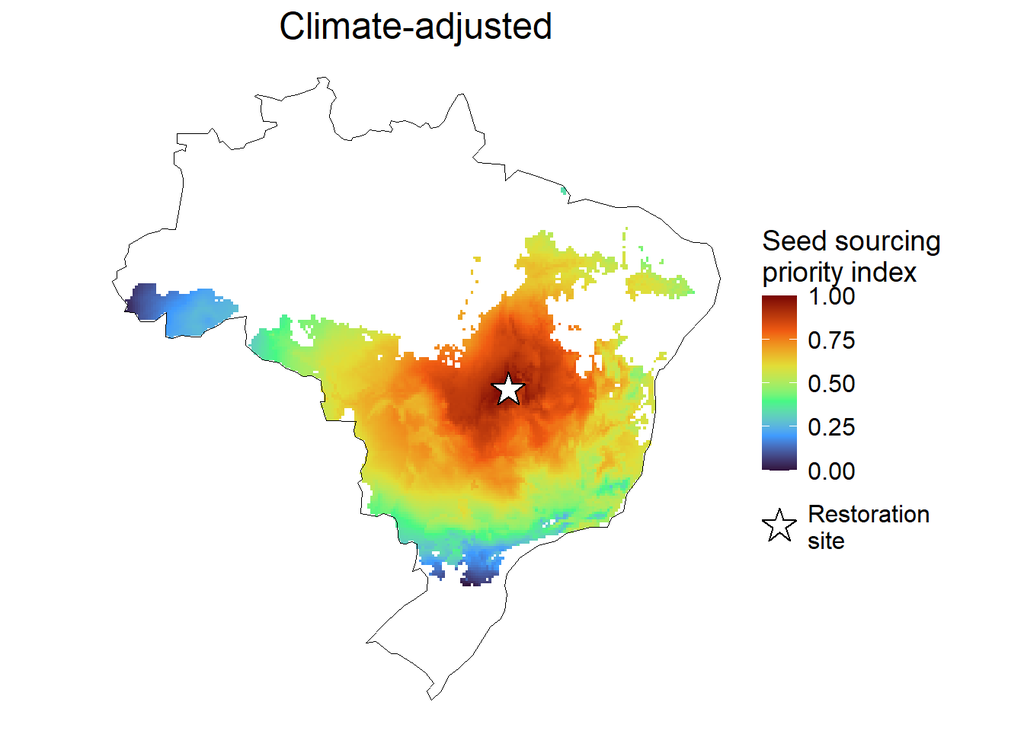

```r
ggplot() +
  geom_tile(data = data.frame(rasterToPoints(prove.proje[[provenance]])),
            aes(x = x, y = y, fill = clima.adjus)) + # Choose between compo, clima.adjus or predi
  geom_sf(data = st_as_sf(exten.proje), colour = "black", fill = NA) +
  scale_fill_viridis_c(option = "turbo", limits = c(0, 1)) +
  labs(fill = "Seed sourcing\npriority index",
       title = "Climate-adjusted",
       starshape = element_blank()) +
  geom_star(data = data.frame(lon = as.numeric(site@coords[1]),
                              lat = as.numeric(site@coords[2]),
                              shp = "Restoration\nsite"), aes(x = lon, y = lat, starshape = shp),
            fill = "white", colour = "black", size = 5, starstroke = .75) +
  theme_void() +
  theme(plot.title = element_text(hjust = 0.5, size = 18),
        legend.title = element_text(size = 14),
        legend.text = element_text(size = 12)) +
  guides(fill = guide_colorbar(order = 1))
```

# Seed sourcing priority between suppliers

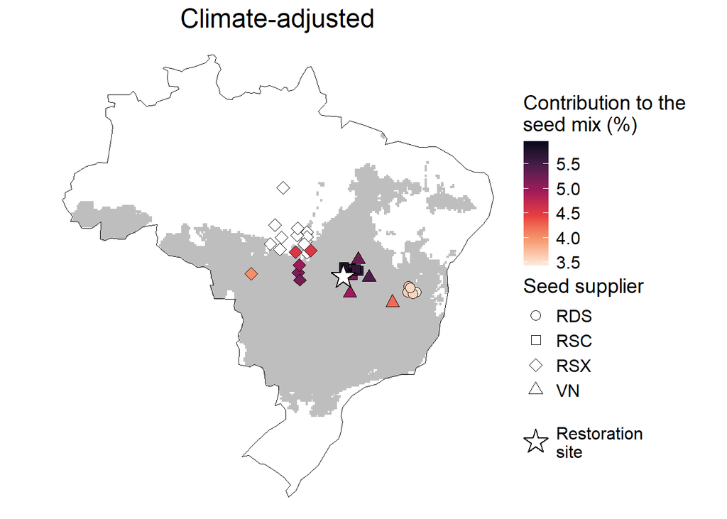

```r
ggplot() +
  geom_tile(data = data.frame(rasterToPoints(prove.proje[[provenance]])),
            aes(x = x, y = y), colour = "grey", fill = "grey") +
  geom_sf(data = st_as_sf(exten.proje), colour = "black", fill = NA) +
  geom_sf(data = st_as_sf(x = cosst.supp, coords = c("long", "lat"),
                          crs = proj4string(prove.proje))$geometry,
          aes(fill = st_as_sf(x = cosst.supp, coords = c("long", "lat"),
                              crs = proj4string(prove.proje))$cosst.perce,
              shape = st_as_sf(x = cosst.supp, coords = c("long", "lat"),
                               crs = proj4string(prove.proje))$supplier),
          size = 3) +
  scale_shape_manual(values = c(21:24)) +
  scale_fill_viridis_c(option = "rocket", direction = -1, na.value = "white") +
  labs(fill = "Contribution to the\nseed mix (%)",
       shape = "Seed supplier",
       title = "Climate-adjusted",
       starshape = element_blank()) +
  geom_star(data = data.frame(lon = as.numeric(site@coords[1]),
                              lat = as.numeric(site@coords[2]),
                              shp = "Restoration\nsite"), aes(x = lon, y = lat, starshape = shp),
            fill = "white", colour = "black", size = 5, starstroke = .75) +
  theme_void() +
  theme(plot.title = element_text(hjust = 0.5, size = 18),
        legend.title = element_text(size = 14),
        legend.text = element_text(size = 12)) +
  guides(fill = guide_colorbar(order = 1),
         shape = guide_legend(order = 2))
```

# Seed demand per supplier

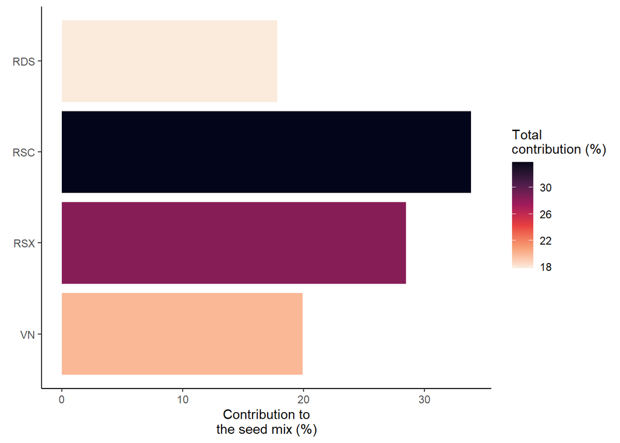

```r
ggplot(data = cosst.supp.summ,
       aes(x = supplier, y = cosst.perce, fill = cosst.perce)) +
  geom_bar(stat = "identity") +
  scale_fill_viridis_c(option = "rocket", direction = -1) +
  scale_x_discrete(limits = c("VN", "RSX", "RSC", "RDS")) +
  labs(x = element_blank(),
       y = "Contribution to\nthe seed mix (%)",
       fill = "Total\ncontribution (%)") +
  theme_classic() +
  coord_flip()
```